[output not shown]

```r
# Use this R-Chunk to import all your datasets!
download("https://byuistats.github.io/M335/data/sales.csv", destfile = "Sales.csv", mode = "wb")

sales <- read_csv("Sales.csv")
```

## Background

[ ] Read in the data from https://byuistats.github.io/M335/data/sales.csv and format it for visualization and analysis [ ] The data are for businesses in the mountain time zone make sure you read in times correctly [ ] This is point of sale (pos) data, so you will need to use library(lubridate) to create the correct time aggregations [ ] Check the data for any inaccuracies [ ] Help your boss understand which business is the best investment through visualizations [ ] Provide an understanding and recommendation for hours of operation [ ] We don’t have employee numbers, but sales traffic can help. Provide some visualizations on customer traffic [ ] Provide a final comparison of the six companies and a final recommendation [ ] Compile your .md and .html file into your git repository [ ] Find two other student’s compiled files in their repository and provide feedback using the issues feature in GitHub (If they already have three issues find a different student to critique) [ ] Address 1-2 of the issues posted on your project and push the updates to GitHub

## Data Wrangling

```r
# Use this R-Chunk to clean & wrangle your data!
sales1 <- sales %>% mutate(
  time = with_tz(Time, tzone = "America/Denver"),
  ceiling_time = ceiling_date(time, unit = "hour"),
  monthly = month(time),
  hourly = hour(time),
  date = date(time),
  weekly = week(time),)

sales2 <- sales1 %>%
  filter(hourly > 1, Name != "Missing")
```

## Data Visualization

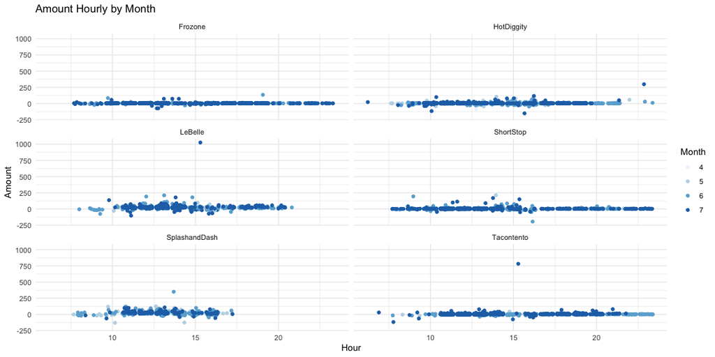

```r
# Use this R-Chunk to plot & visualize your data!
ggplot(sales2)+
  geom_jitter(aes(x = hourly, y = Amount, col = as.factor(monthly)))+
  scale_colour_brewer()+
  facet_wrap(~ Name, nrow=3)+
  theme_minimal()+
  labs(x = "Hour", y = "Amount", title = "Amount Hourly by Month", color = "Month")
```

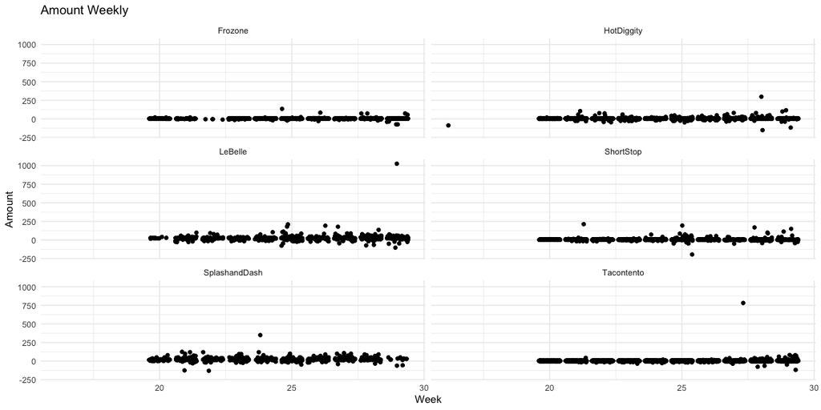

```r
ggplot(sales2)+
  geom_jitter(aes(x = weekly, y = Amount))+
  facet_wrap(~ Name, nrow=3)+
  theme_minimal()+
  labs(x = "Week", y = "Amount", title = "Amount Weekly")
```